# Lab 8: Interpolation

Learning objectives:

- Explore interpolation conceptually, **not** focusing on formulas like the Barycentric formula nor Newton's divided differences
- Visualize how Lagrange polynomials work
- If the data $y$ are generated by $y=f(x)$, and we interpolate with a polynomial $p$, then we have an error $e(x) = f(x)-p(x)$
  - Explore where (in the $x$ domain) the error is the highest
  - Consider using nonuniformly spaced $x$ nodes and see the effect on error
  - If we refine with $n\to \infty$, does $|e(x)|$ get smaller? Is this true for some functions but not others? What properties of the functions might affect it?
- Understand that polynomial interpolation comes down to linear algebra
  - The Vandermonde matrices for a given basis are useful (even if our practical formulas avoid forming/solving them explicitly)

Tasks:

1. Lagrange interpolation "by hand"
2. Trying different node locations: uniform or nonuniform (clustered near edges)
3. Look at the error formula for 3 functions, $f(x)=e^{-x}$, $f(x)=\frac{1}{1+x^2}$, and $f(x)=|x|$.
4. Make Vandermonde matrices by hand; solve for the coefficients; and create the polynomial

*If you are super speedy and finish everything quickly, then look into https://github.com/chebpy/chebpy, a Python wrapper for [chebfun](https://www.chebfun.org/), which is a numerical package (originally in Matlab) for defining functions via their polynomial interpolants (using the [Chebyshev polynomial basis](https://en.wikipedia.org/wiki/Chebyshev_polynomials) )*

**Deliverables**

Turn in a **single PDF** with the following items:

- from Task 1, a plot of the $k=2$ Lagrange polynomial for the given nodes described in that task
- from Task 2, a plot of the error, for $n=9$, for both uniform and nonuniform nodes (combined onto a single plot)
- from Task 3, a sentence commenting on your results (if you finished) or speculation on what your results would be (if you didn't finish)

No deliverables from Task 4 are required

APPM 4600. Copyright Department of Applied Mathematics, University of Colorado Boulder. Released under a BSD 3-clause license

```python
import numpy as np
import scipy.interpolate
import sympy
from   matplotlib import pyplot as plt
```

## Part 1: Lagrange interpolation "by hand"

We'll do Lagrange interpolation, but do it manually, not using the Barycentric formula. This is for illustrative purposes

Use the `xData` and `yData` points given below (both of length 5). Create a Python function that returns the $k^\text{th}$ Lagrange polynomial (for $k=0,1,2,3,4$) for these `xData` nodes. Plot the $k=2$ polynomial (evaluating it at 50 points) in the range $[1,5]$.

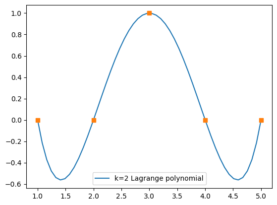

```python
xData = np.arange(1,6)
yData = np.array( [3.1, 1.6, 3.5, 4.6, 5.8])

# Or, another way
def L(x,k):
    """ returns the value of the kth Lagrange polynomial,
    evaluated at a given point x
    (note: k is 0-indexed) """

    n = len(xData)

    prod = 1
    for i in range(n):
        if i != k:
            prod *= (x - xData[i])/(xData[k] - xData[i])

    return prod

# Plot k=2 polynomial
k = 2

Lk = lambda x : L(x,k)

xGrid = np.linspace(1,5,50) # for plotting
plt.plot( xGrid, Lk(xGrid), label=f'k={k} Lagrange polynomial')
plt.plot( xData, Lk(xData), 's')
plt.legend()
plt.show()
```

Now build the interpolating polynomial. You don't need to do this in an "automated" fashion. Plot this polynomial (again, at 50 data points in the range $[1,5]$) as well as the original `xData` and `yData`

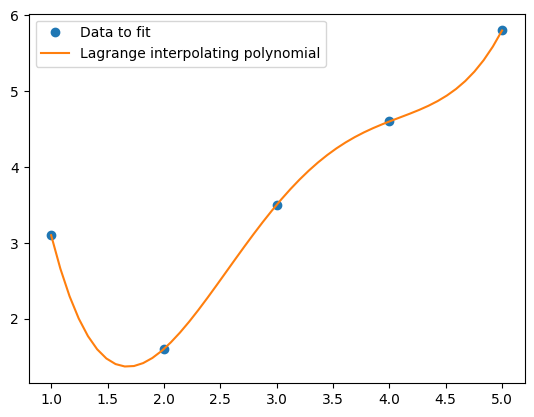

```python
def p(x):
    """ returns the value of the interpolating polynomial,
    evaluated at a given point x """

    n = len(xData)

    sum = 0
    for i in range(n):
        sum += yData[i] * L(x, i)

    return sum

plt.plot(xData,yData, 'o', label='Data to fit')

xGrid = np.linspace(1,5,50) # for plotting
plt.plot( xGrid, p(xGrid), label='Lagrange interpolating polynomial')
plt.legend()
plt.show()
```

## Part 2: Node locations

Consider the function $f(x) = e^{-5x^2}$ on the interval $[-1,1]$, and take $n+1$ nodes on $[-1,1]$. Evaluate $f$ on these nodes to get the $y$ values. Using the $x$ and $y$ data, create the interpolating polynomial $p(x)$ using `scipy.interpolate.BarycentricInterpolator`

1. Do this for **equally spaced** nodes, e.g., `np.linspace(-1,1,n+1)`
2. Repeat this for the following **unequally** spaced nodes: $x_j = \cos(\frac{j\pi}{n})$ for $j=0,1,\ldots,n$. (These are the "Chebyshev points" used in [Clenshaw-Curtis quadrature](https://epubs.siam.org/doi/epdf/10.1137/060659831))

Do this for $n=9$ (so 10 points total)

In both cases, make a plot of:

1. the data and both interpolants $p(x)$
2. the error between the original function $f(x)$ and both interpolants $p(x)$ For the plot, evaluate on a fine grid, e.g., 200 equally spaced points between $[-1,1]$

Answer the following questions:

1. For **equally spaced nodes**, where is most of the error located (in terms of $x$ values), e.g., near the center? near the edges?
2. If you make $n=19$, compare the maximum error $f(x)-p(x)$ for both cases. Which type of nodes (equally spaced or unequally spaced) has less error?

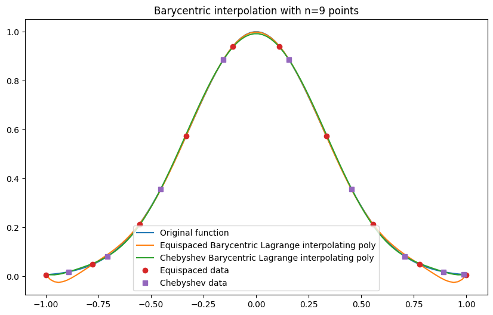

```python
def part2(n = 9, a = -1, b = 1, f = lambda x : np.exp(-5*x**2) ):
    from matplotlib import pyplot as plt
    import numpy as np

    xData_equispaced = np.linspace(a, b, n+1)
    xData_chebyshev = np.array( [ np.cos((2*k+1)*np.pi/(2*(n+1))) for k in range(n) ] )

    yData_equispaced = f(xData_equispaced)
    yData_chebyshev = f(xData_chebyshev)

    equispace_interp = scipy.interpolate.BarycentricInterpolator(xData_equispaced, yData_equispaced)
    chebyshev_interp = scipy.interpolate.BarycentricInterpolator(xData_chebyshev, yData_chebyshev)

    # Plot the two interpolating polynomials, and the original function, and data on the same plot, with labels
    xGrid = np.linspace(-1,1,100)
    plt.figure(figsize=(10,6))
    plt.plot(xGrid, f(xGrid), label='Original function')
    plt.plot(xGrid, equispace_interp(xGrid), label='Equispaced Barycentric Lagrange interpolating poly')
    plt.plot(xGrid, chebyshev_interp(xGrid), label='Chebyshev Barycentric Lagrange interpolating poly')
    plt.plot(xData_equispaced, yData_equispaced, 'o', label='Equispaced data')
    plt.plot(xData_chebyshev, yData_chebyshev, 's', label='Chebyshev data')
    plt.title(f'Barycentric interpolation with n={n} points')
    plt.legend()
    plt.show()

part2()
```

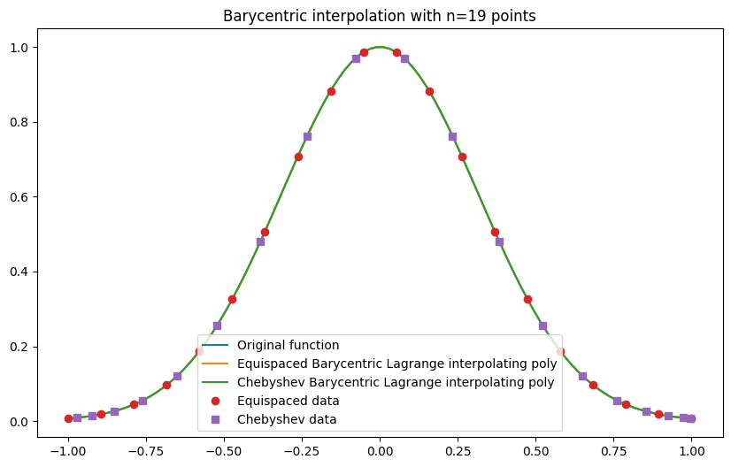

```python
# Repeat, but for larger n
n     = 19
part2(n)
```

## Part 3: Error formulas for different types of functions

If $p_n$ is the interpolating polynomial on $n+1$ nodes $\{x_0,x_1,\ldots,x_n\}$ then we have the Lagrange remainder formula

$$f(x) - p_n(x) = \frac{f^{(n+1)}(\xi)}{(n+1)!} \prod_{i=0}^n (x-x_i)$$ for some $\xi$ in between the nodes. (See our notes, or our book, or [wikipedia: "Interpolation error: Lagrange remainder formula"](https://en.wikipedia.org/wiki/Polynomial_interpolation#Interpolation_error:_Lagrange_remainder_formula))

### Part 3a

Compare the error, using three different "$f$" functions:

1. $f(x)=e^{-x}$
2. $f(x) = \frac{1}{1+x^2}$
3. $f(x)=|x|$

on $[-5,5]$ using $n+1$ **equispaced nodes**. To find the polynomial interpolant, use the `scipy.interpolate.BarycentricInterpolator` function again.

Record and the maximum error, $\max_{x\in[-5,5]} |f(x)-p(x)|$, for each choice of $f$ and its respective interpolant. (You don't need to calculate this error exactly, just approximate it by evaluating $f(x)-p(x)$ on a dense grid of $x$ points, e.g., 200 $x$ values in $[-5,5]$ is plenty).

Record this max error as a function of $n$, for $n=1,2,\ldots,50$.

(You may find it helpful to plot $f(x)$ and $p(x)$ if you like)

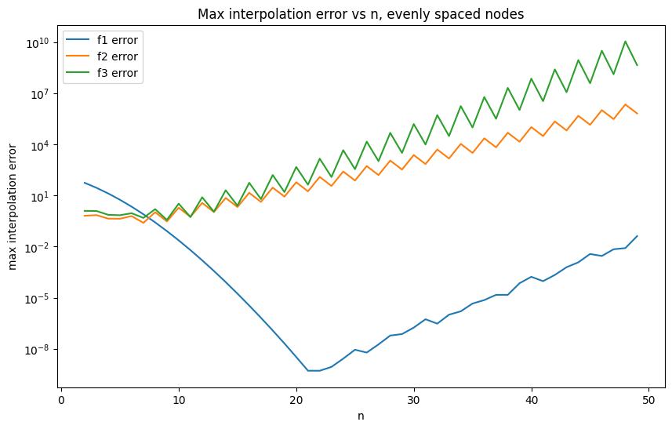

```python
a, b = -5, 5

f1 = lambda x : np.exp(-x)
f2 = lambda x : 1/(1+x**2)
f3 = lambda x : np.abs(x)


def max_interp_error(f, interp, xGrid):
    return np.max( np.abs(f(xGrid) - interp(xGrid)) )

def fn_interp_error(f, a, b, n):
    xGrid = np.linspace(a, b, n)

    f_interp = scipy.interpolate.BarycentricInterpolator(xGrid, f(xGrid))

    xFine = np.linspace(a, b, 100*n)

    return max_interp_error(f, f_interp, xFine)

nGrid = np.arange(2, 50)
f1_errors = [ fn_interp_error(f1, a, b, n+1) for n in nGrid ]
f2_errors = [ fn_interp_error(f2, a, b, n+1) for n in nGrid ]
f3_errors = [ fn_interp_error(f3, a, b, n+1) for n in nGrid ]

plt.figure(figsize=(10,6))
plt.plot(nGrid, f1_errors, label='f1 error')
plt.plot(nGrid, f2_errors, label='f2 error')
plt.plot(nGrid, f3_errors, label='f3 error')
plt.yscale('log')
plt.xlabel('n')
plt.ylabel('max interpolation error')
plt.title('Max interpolation error vs n, evenly spaced nodes')
plt.legend()
plt.show()
```

### Part 3b: try the Chebyshev nodes

In our formula for the error, we have the term $$f(x) - p_n(x) = \frac{f^{(n+1)}(\xi)}{(n+1)!} \prod_{i=0}^n (x-x_i)$$

We don't have control over $\xi$, but if we want to place nodes $n+1$ nodes $x_i$ in the interval $[-a,a]$, we could try to do so in a manner to minimize $$\max_{x\in[-a,a]} \left| \prod_{i=0}^n (x-x_i) \right|.$$ Doing this leads to the Chebyshev nodes (scaled by $a$) that we already saw.

So let's repeat 3a but this time use Chebyshev nodes instead of uniform nodes. Does this help?

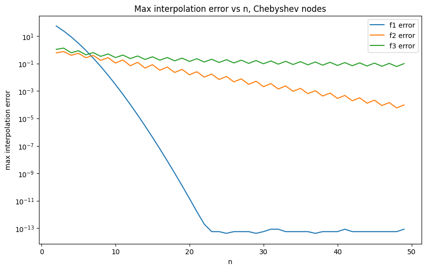

```python
a, b = -5, 5

f1 = lambda x : np.exp(-x)
f2 = lambda x : 1/(1+x**2)
f3 = lambda x : np.abs(x)


def max_interp_error(f, interp, xGrid):
    return np.max( np.abs(f(xGrid) - interp(xGrid)) )

def fn_interp_error(f, a, b, n):
    xGrid = 0.5*(a+b) + 0.5*(b-a)*np.cos((2*np.arange(1, n+1)-1)*np.pi/(2*n))  # Chebyshev nodes

    f_interp = scipy.interpolate.BarycentricInterpolator(xGrid, f(xGrid))

    xFine = np.linspace(a, b, 100*n)

    return max_interp_error(f, f_interp, xFine)

nGrid = np.arange(2, 50)
f1_errors = [ fn_interp_error(f1, a, b, n+1) for n in nGrid ]
f2_errors = [ fn_interp_error(f2, a, b, n+1) for n in nGrid ]
f3_errors = [ fn_interp_error(f3, a, b, n+1) for n in nGrid ]

plt.figure(figsize=(10,6))
plt.plot(nGrid, f1_errors, label='f1 error')
plt.plot(nGrid, f2_errors, label='f2 error')
plt.plot(nGrid, f3_errors, label='f3 error')
plt.yscale('log')
plt.xlabel('n')
plt.ylabel('max interpolation error')
plt.title('Max interpolation error vs n, Chebyshev nodes')
plt.legend()
plt.show()
```

**Analysis**: This data makes sense. With the evenly spaced nodes, the error is increasing as n goes up. This is due to the Runge phenomenon, creating a large maximum error for large n as the ringing gets more and more pronounced. The Chebyschev nodes supress the Runge phenomenon and allow the error to decrease.

## Part 4: Generalized Vandermonde matrices for different bases

For each of the three sets of polynomial bases (monomials, Lagrange polynomials, and Newton polynomials), we have provided code below to generate a list that contains the polynomial functions of that basis. (Note: you can also define the shifted monomial basis easily using the regular monomial basis)

Your job is to create the Vandermonde matrix (for the given nodes `xData`), and then find the coefficients by solving the linear system, and then using those coefficients to create the final interpolating polynomial.

```
Monomial basis
[[     1.       10.      100.     1000.    10000.   100000.  ]
 [     1.       10.2     104.04   1061.21  10824.32 110408.08]
 [     1.       10.4     108.16   1124.86  11698.59 121665.29]
 [     1.       10.6     112.36   1191.02  12624.77 133822.56]
 [     1.       10.8     116.64   1259.71  13604.89 146932.81]
 [     1.       11.      121.     1331.    14641.   161051.  ]]
Condition number of Vandermonde matrix is 1.88e+13
Lagrange basis functions at xData:
L_0(xData) = [ 1. -0.  0. -0.  0. -0.]
L_1(xData) = [ 0.  1. -0.  0. -0.  0.]
L_2(xData) = [-0.  0.  1. -0.  0. -0.]
L_3(xData) = [ 0. -0.  0.  1. -0.  0.]
L_4(xData) = [-0.  0. -0.  0.  1. -0.]
L_5(xData) = [ 0. -0.  0. -0.  0.  1.]
Lagrange basis
[[ 1.  0. -0.  0. -0.  0.]
 [-0.  1.  0. -0.  0. -0.]
 [ 0. -0.  1.  0. -0.  0.]
 [-0.  0. -0.  1.  0. -0.]
 [ 0. -0.  0. -0.  1.  0.]
 [-0.  0. -0.  0. -0.  1.]]
Condition number of Vandermonde matrix is 1.00e+00
Newton basis
[[ 1.    0.   -0.    0.   -0.    0.  ]
 [ 1.    0.2   0.   -0.    0.   -0.  ]
 [ 1.    0.4   0.08  0.   -0.    0.  ]
 [ 1.    0.6   0.24  0.05  0.   -0.  ]
 [ 1.    0.8   0.48  0.19  0.04  0.  ]
 [ 1.    1.    0.8   0.48  0.19  0.04]]
Condition number of Vandermonde matrix is 1.36e+03
Lagrange basis functions at xData:
L_0(xData) = [ 1. -0.  0. -0.  0. -0.]
L_1(xData) = [ 0.  1. -0.  0. -0.  0.]
L_2(xData) = [-0.  0.  1. -0.  0. -0.]
L_3(xData) = [ 0. -0.  0.  1. -0.  0.]
L_4(xData) = [-0.  0. -0.  0.  1. -0.]
L_5(xData) = [ 0. -0.  0. -0.  0.  1.]
```

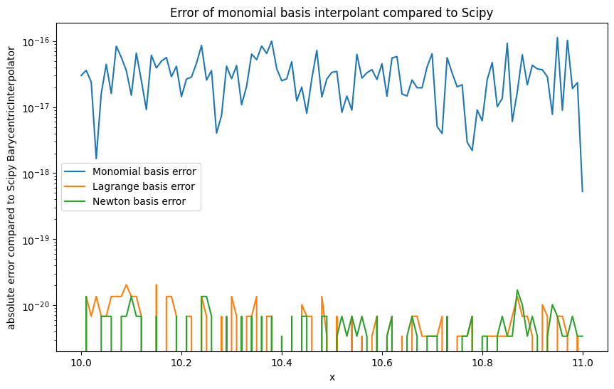

```python
n     = 5
xData = np.linspace(10,11,n+1)
f     = lambda x : np.exp(-x)
yData = f(xData)

def createMonomialBasis(n):
    basis = []
    for k in range(n+1):
        # due to Python's "late binding" we have to do some tricks
        # See https://stackoverflow.com/a/2295372, https://stackoverflow.com/q/3431676
        basis.append(  lambda z,k=k : z**k )
    return basis

def createLagrangeBasis(n, xData):
    basis = []
    for k in range(n+1):
        def L_nk(x,k=k):
            y = 1.
            for j in range(k):
                y *= (x-xData[j])/( xData[k]-xData[j])
            for j in range(k+1,len(xData)):
                y *= (x-xData[j])/( xData[k]-xData[j])
            return y
        basis.append( L_nk )
    print('Lagrange basis functions at xData: ')
    for i, b in enumerate(basis):
        print(f'L_{i}(xData) = {b(xData)}')
    return basis

def createNewtonBasis(n,xData):
    basis = []
    for k in range(n+1):
        def L_nk(x,k=k):
            y = 1.
            for j in range(k):
                y *= (x-xData[j])
            return y
        basis.append( L_nk )
    return basis

def createVandermonde(xData, basis):
    # this is for you to implement
    n = len(xData)
    V = np.zeros((n,n))
    for i in range(n):
        for j in range(n):
            V[i,j] = basis[j](xData[i])
    return V

# Then, for each basis, create the Vandermonde matrix, e.g.,
V_monomial = createVandermonde(xData, createMonomialBasis(n) )
with np.printoptions(precision=2,suppress=True):
    print('Monomial basis')
    print(V_monomial)
    kappa = np.linalg.cond(V_monomial)
    print(f'Condition number of Vandermonde matrix is {kappa:.2e}')
    # Rule-of-thumb: log10(kappa) is how many digits we lose when we
    # solve a system involving the matrix. So if kappa=1e12 and we work
    # in double precision with about 16 digits, we'd expect our answer to
    # only be accurate to about 4 digits. Not very good!

# For each basis, solve for the coefficients "c"
c_monomial = np.linalg.solve(V_monomial, yData)

V_lagrange = createVandermonde(xData, createLagrangeBasis(n, xData) )
with np.printoptions(precision=2,suppress=True):
    print('Lagrange basis')
    print(V_lagrange)
    kappa = np.linalg.cond(V_lagrange)
    print(f'Condition number of Vandermonde matrix is {kappa:.2e}')
c_lagrange = np.linalg.solve(V_lagrange, yData)


V_newton = createVandermonde(xData, createNewtonBasis(n, xData) )
with np.printoptions(precision=2,suppress=True):
    print('Newton basis')
    print(V_newton)
    kappa = np.linalg.cond(V_newton)
    print(f'Condition number of Vandermonde matrix is {kappa:.2e}')
c_newton = np.linalg.solve(V_newton, yData)



# And then create the polynomial interpolant using the coefficients and basis
def poly_interp(x, c, basis):
    y = 0.
    for k in range(len(c)):
        y += c[k]*basis[k](x)
    return y

# If you want to check that you have the right interpolant, compare with Scipy:
# We'll treat this as the "ground truth" (it's a stable formula, and presumably a bug-free implementation):
p     = scipy.interpolate.BarycentricInterpolator(xData,yData)
# compare with our monomial interpolant at some test points

xTest = np.linspace(10,11,20*n+1)

# Plot relative error for each basis compared to Scipy with matplotlib
plt.figure(figsize=(10,6))
plt.plot(xTest, np.abs(poly_interp(xTest, c_monomial, createMonomialBasis(n) ) - p(xTest)), label='Monomial basis error')
plt.plot(xTest, np.abs(poly_interp(xTest, c_lagrange, createLagrangeBasis(n, xData) ) - p(xTest)), label='Lagrange basis error')
plt.plot(xTest, np.abs(poly_interp(xTest, c_newton, createNewtonBasis(n, xData) ) - p(xTest)), label='Newton basis error')
plt.yscale('log')
plt.xlabel('x')
plt.ylabel('absolute error compared to Scipy BarycentricInterpolator')
plt.title('Error of monomial basis interpolant compared to Scipy')
plt.legend()
plt.show()
```

```python
# Sanity check using some of numpy's builtin polynomial functionality
from numpy.polynomial import Polynomial
from numpy.polynomial import polynomial as P

?P.polyvander

# and you can do something similar with the Chebyshev basis
# ?np.polynomial.chebyshev.chebvander
```

[output not shown]